# ASFB 2026: Acoustic Telemetry Workshop (R practical)

Innovasea & IMOS Animal Tracking Facility

Hugh Pederson & Yuri Niella

2026-12-29

# Session preparation

## Installing R packages

RangeR (range testing) and ranger (gapFinder’s machine-learning engine) are different packages whose names differ only by capitalization. To keep both on case-insensitive filesystems, use a separate project library for ranger:

```r
workshop_lib <- file.path(".R-library")
dir.create(workshop_lib, showWarnings = FALSE, recursive = TRUE)
.libPaths(c(.libPaths(), normalizePath(workshop_lib)))
```

You will need to install the following packages from CRAN:

```r
install.packages(c("patchwork", "dplyr", "tidyr", "suncalc", "remotes",
  "tidyverse", "classInt"))
install.packages("ranger", lib = workshop_lib)
```

And from GitHub:

- **FathomR**

```r
remotes::install_github("Fish-Tracking-Data-Team/FathomR",
  build_vignettes = TRUE,
  dependencies = TRUE)
```

- **RangeR**

```r
remotes::install_github("Fish-Tracking-Data-Team/RangeR",
                        build_vignettes = TRUE,
                        dependencies = TRUE)
```

- **gapFinder**

```r
remotes::install_github("IMOS-AnimalTracking/gapFinder",
  build_opts = c("--no-resave-data", "--no-manual"),
  build_vignettes = TRUE)
```

- **remora**

```r
remotes::install_github("IMOS-AnimalTracking/remora",
  build_vignettes = TRUE,
  dependencies = TRUE)
```

For interactive use, set your working directory to the folder containing the workshop materials. When rendering, R Markdown uses the directory containing this document:

```r
options(width = 70) # Console width setting
```

# Analysis Session 1

## 1.1 FathomR - Rapid Ingestion of Fathom csv files into R

### 1.1.1 Load the FathomR package

```r
library(FathomR)
library(dplyr)
```

### 1.1.2 Inspect logfile metadata and schema

```r
# inspect logfile metadata
log.file.details <- inspect_receiver_log_index(
  directory_path = './Data/FathomR/'
)

fathom.schema <- peek_fathom_schema(
  directory_path = './Data/FathomR/'
)
```

```
##
## Fathom schema peek (high level)
## Directory: ./Data/FathomR/
## Files: 5
## Record types: 29
##
## # A tibble: 29 × 5
##    record_type  n_files_present n_files_total n_columns n_example_rows
##    <chr>                  <int>         <int>     <int>          <int>
##  1 attitude                   5             5         7              5
##  2 battery                    5             5        11              5
##  3 cfg_channel                5             5        12              5
##  4 cfg_station                5             5         9              1
##  5 cfg_study                  5             5         7              3
##  6 cfg_transmi…               5             5        12              3
##  7 clock_ref                  5             5         9              5
##  8 clock_set                  5             5         9              5
##  9 data_error                 5             5         5              0
## 10 data_source…               5             5         5              5
## # ℹ 19 more rows
```

### 1.1.3 Ingest logfiles

```r
# ingest fathom logfiles into a list object
data <- parse_fathom_files(
  './Data/FathomR/', output = 'list'
)


# alternatively, ingest fathom logfiles into individual tibbles
parse_fathom_files(
        './Data/FathomR/', output = 'env',
        as_tibble = TRUE
)
```

### 1.1.4 Leveraging FathomR data structure

```r
# Removing receiver self-transmitter detections

self.transmit.ids <- cfg_transmitter$`Full ID`

# isolate animal detections

animal.dets <- det %>%
    filter(!`Full ID` %in% self.transmit.ids)
```

## 1.2. Range Testing - Drift Range Test (RangeR package and DriftR app demo)

### 1.2.1 Load required packages

```r
library(FathomR)
library(RangeR)
```

### 1.2.2 Load Receiver Logfiles

Parse the receiver logfiles into a list object containing the detections and diagnostics needed for the workflow.

```r
data <- FathomR::parse_fathom_files(
  "./Data/range_test/drift_test/logfiles",
  output = "list"
)
```

### 1.2.3 Define Transmission Source

Set the transmission source for the workflow.

```r
transmission_source <- "VR100"
```

### 1.2.4 Define Station Metadata

Station metadata can be created in place or read from a file. resolve_station_location() standardises the input and returns the selected station row together with a station_location vector that can be passed into downstream RangeR functions.

```r
stations <- data.frame(
  latitude = c(-42.6665),
  longitude = c(147.9767),
  Serial = c(548851)
)

stations <- resolve_station_location(
  stations = stations,
  station_row = NULL
)
```

If you have multiple stations, either set station_row explicitly or leave it as NULL in an interactive session to choose a row.

### 1.2.5 Select Transmitters and Devices

The bundled drift test uses two range-test transmitters, receiver 548851, and VR100 12254. Set these explicitly so the document can render without console input.

```r
det <- data$det # create a data frame of detections

transmitters <- c("A69-1602-62107", "A69-1602-62108")

devices <- list(receiver_serial = 548851, VR100_serial = 12254)
```

For other datasets, run these selectors interactively to choose transmitters and devices:

```r
transmitters <- select_range_transmitter(
  det = det,
  transmission_source = transmission_source
)

devices <- select_devices(
  det = det,
  transmission_source = transmission_source
)
```

### 1.2.6 Qualify Receiver Receiver Diagnostics

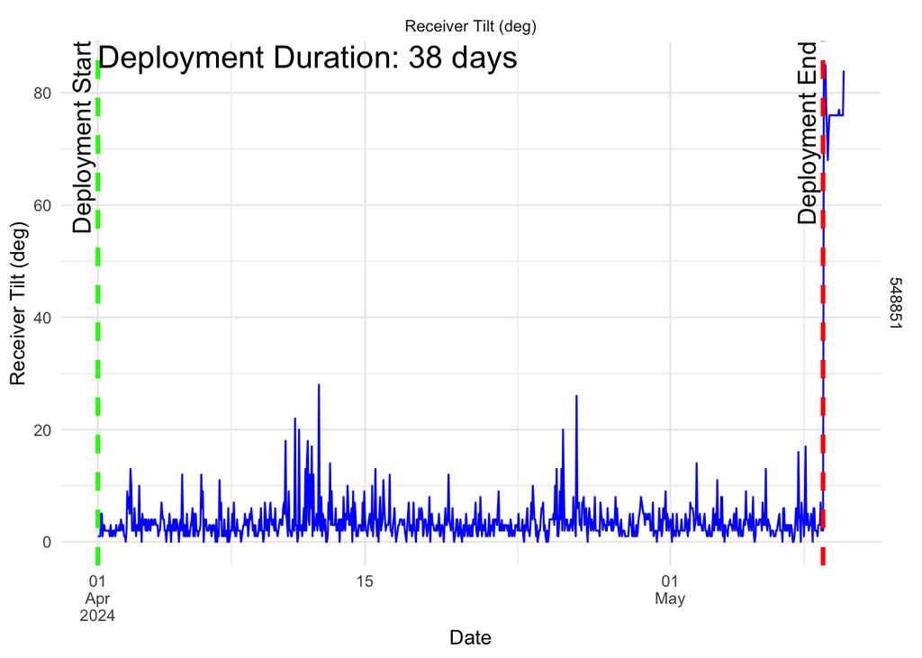

```r
diag <- data$diag

deployment_times <- get_deployment_time(
  diag_fast = diag,
  min_tilt = 0,
  max_tilt = 60,
  n = 5
)

plot_deployment_windows(
  diag_data = diag,
  deployment_time_result = deployment_times
)
```

```r
# Optional: manual modification of deployment times
# deployment_times$maxTime <- deployment_times$maxTime + 86400
```

### 1.2.7 Run Drift Range Analysis

```r
range_est <- run_drift_range_analysis(
  det = det,
  start_time = deployment_times$minTime,
  end_time = deployment_times$maxTime,
  devices = devices,
  transmitter_ids = transmitters,
  station_location = stations$station_location,
  transmission_source = transmission_source,
  synthetic_transmit_data = NULL,
  time_buffer = 5,
  dist_threshold = 1200,
  prediction_distance_max = 1200
)
```

### 1.2.8 Plot Results

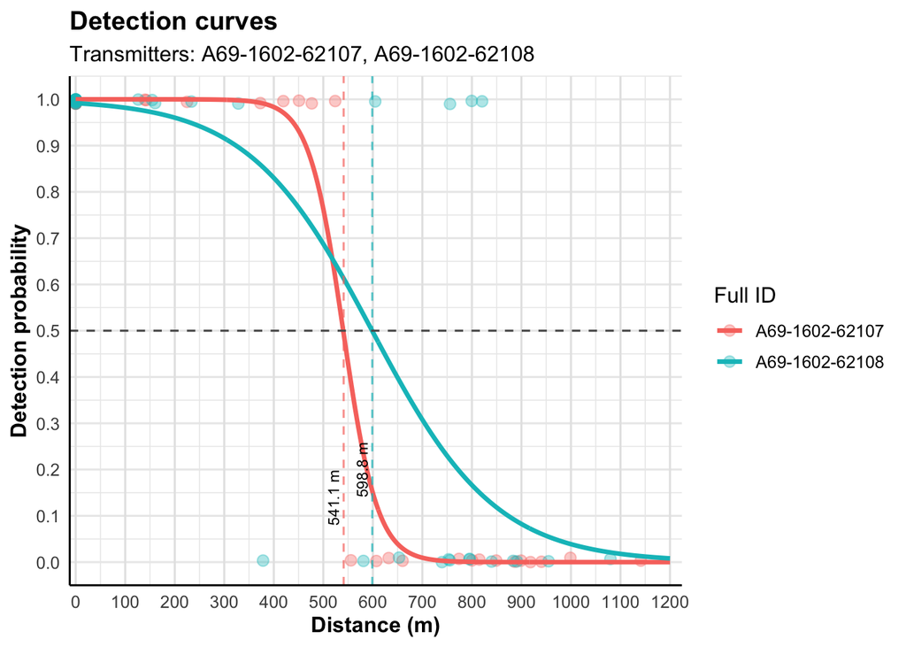

```r
plot_drift_results(
  range_est,
  title = if (length(transmitters) == 1) {
    paste0("Detection curve for ", transmitters)
  } else {
    "Detection curves"
  },
  subtitle = paste("Transmitters:", paste(transmitters, collapse = ", ")),
  x_limits = c(0, 1200),
  x_breaks = seq(0, 1200, 100)
)
```

## 1.3 Static Range Test

### 1.3.1 Load required packages

```r
library(FathomR)
library(RangeR)
library(padr)
library(data.table)
library(tibble)
library(gridExtra)
```

### 1.3.2 Identify stations

```r
# load station metdata
stations <- readr::read_csv('./Data/range_test/static_test/metadata/deployment_metadata.csv')

# standardise stations dataframe
receiver_prep <- RangeR::prepare_distance_df(stations, lat_col = 'latitude',
                                            long_col = 'longitude', station_col = 'Station',
                                            serial_col = 'Serial')


# Load receiver logfiles
data <- parse_fathom_files('./Data/range_test/static_test/logfiles') # parse fathom interleaved csv
```

### 1.3.3 Calculate distances between stations

```r
# calculate distances between the reference and all other stations
distance_df <- RangeR::receiver_separations(receiver_prep, reference_station = c('RT2'))
```

### 1.3.4 Identify Deployment Times

```r
# computet the deployment times using receiver diagnostics
deployment_times <- get_deployment_time(data$diag, min_tilt = 6, max_tilt = 40, 5)


# check deployment duration
as.numeric(deployment_times$maxTime - deployment_times$minTime)
```

```
## [1] 30.9175
```

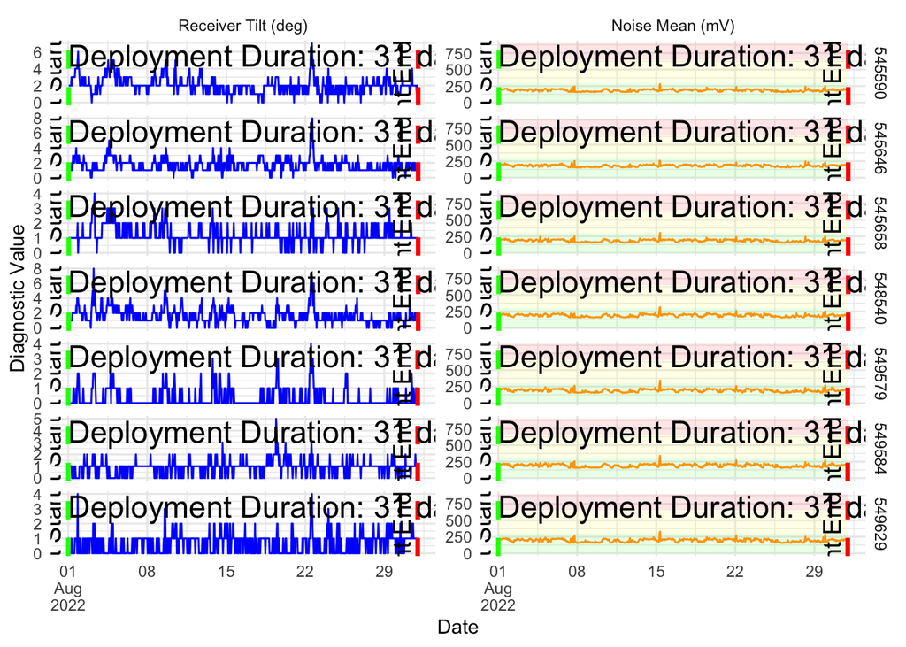

```r
# plot receiver diagnostics (tilt and noise)
plot_deployment_windows(data$diag, deployment_times, diagnostic = 'both')
```

### 1.3.5 Extract range transmitter ID

```r
# extract the transmitter programming of the reference station
transmitters <- transmitter_config(data$cfg_transmitter, distance_df)
```

### 1.3.6 Calculate receiver detection range

```r
range <- calculate_range(data$det, transmitters,
                        distance_df,
                        deployment_times$minTime,
                        deployment_times$maxTime,
                        nom_delay = transmitters$nom_delay,
                        prediction_distance_max = 1500)
```

[figure not shown]

## 1.4. Receiver performance and diagnostics - gapFinder package walkthrough

### Load packages

```r
library(FathomR)
library(gapFinder)
library(patchwork)
library(dplyr)
library(tidyr)
library(suncalc)
```

### Load receiver logs

Load Fathom csv files exported from [Fathom Central](https://fathomcentral.com/learn) and stored on disk:

```r
fathom_dets <- parse_fathom_files("Data/gapFinder/Fathom",
  output = "list")
```

### Match deployment metadata

The raw receiver log files will need to be matched to receiver deployment metadata, so that gapFinder can assing them to the correct stations, and process only the data for when the receivers were in the water.

```r
# Example metadata file
meta_file <- read.csv("Data/gapFinder/Receiver metadata.csv")

meta_file
```

```
##   station_name receiver_name    transmit_id
## 1       MIL 10  VR2AR-549579 A69-1601-60008
## 2          RT2  VR2AR-549584 A69-1601-60013
##   receiver_deployment_datetime receiver_deployment_longitude
## 1          2022-05-04 00:14:00                      148.2085
## 2          2022-05-04 02:00:00                      148.2098
##   receiver_deployment_latitude receiver_recovery_datetime    status
## 1                    -42.66467        2023-05-01 23:47:00 RECOVERED
## 2                    -42.66711        2023-05-02 00:13:00 RECOVERED
##   Comment     type
## 1      NA receiver
## 2      NA receiver
```

```r
# Match metadata and Fathom files
dets_sort <- match_meta(input = fathom_dets,
  path_meta = "Data/gapFinder/Receiver metadata.csv",
  receiver_id = "receiver_name",
  transmitter_id = "transmit_id",
  type = "type",
  station_name = "station_name",
  deploy_datetime = "receiver_deployment_datetime",
  recover_datetime = "receiver_recovery_datetime",
  lat = "receiver_deployment_latitude",
  lon = "receiver_deployment_longitude",
  tz = "UTC")
```

```r
names(dets_sort)
```

```
##  [1] "attitude"         "battery"          "cfg_channel"
##  [4] "cfg_station"      "cfg_study"        "cfg_transmitter"
##  [7] "clock_ref"        "clock_set"        "data_error"
## [10] "data_source_file" "depth"            "depth_stats"
## [13] "det"              "det_filter"       "diag"
## [16] "diag_fast"        "event"            "event_fault"
## [19] "event_init"       "event_offload"    "health_vr2ar"
## [22] "temp"             "temp_stats"
```

```r
# Detections
head(as.data.frame(dets_sort$det))
```

```
##          Device Time (UTC)                Time Time Offset (h)
## 1 2022-05-05 00:01:29.6512 2022-05-05 00:01:31
## 2 2022-05-05 00:02:48.8554 2022-05-05 00:02:51
## 3 2022-05-05 00:02:52.5338 2022-05-05 00:02:54
## 4 2022-05-05 00:07:06.6973 2022-05-05 00:07:09
## 5 2022-05-05 00:08:08.3475 2022-05-05 00:08:10
## 6 2022-05-05 00:10:37.4485 2022-05-05 00:10:39
##   Time Correction (s) Model Detection Type        Full ID    ID
## 1         2.340238875 VR2AR            PPM A69-1601-60763 60763
## 2         2.341005228 VR2AR            PPM A69-1601-61004 61004
## 3         2.341040819 VR2AR            PPM A69-1601-60122 60122
## 4         2.343500018 VR2AR            PPM A69-1601-60008 60008
## 5         2.344096525 VR2AR            PPM A69-1601-60013 60013
## 6         2.345539175 VR2AR            PPM A69-1601-60763 60763
##   Signal Strength (dB) Noise (dB) Quality Score Decoder Sensor Value
## 1
## 2
## 3
## 4
## 5
## 6
##   Sensor Unit Serial deploy_id station_name
## 1             549579         1       MIL 10
## 2             549579         1       MIL 10
## 3             549579         1       MIL 10
## 4             549579         1       MIL 10
## 5             549579         1       MIL 10
## 6             549579         1       MIL 10
##   receiver_deployment_latitude receiver_deployment_longitude
## 1                    -42.66467                      148.2085
## 2                    -42.66467                      148.2085
## 3                    -42.66467                      148.2085
## 4                    -42.66467                      148.2085
## 5                    -42.66467                      148.2085
## 6                    -42.66467                      148.2085
```

```r
# Diagnostic
head(as.data.frame(dets_sort$diag))
```

```
##     Device Time (UTC)                Time Time Offset (h)
## 1 2022-05-04 01:00:00 2022-05-04 01:00:01
## 2 2022-05-04 02:00:00 2022-05-04 02:00:01
## 3 2022-05-04 03:00:00 2022-05-04 03:00:01
## 4 2022-05-04 04:00:00 2022-05-04 04:00:01
## 5 2022-05-04 05:00:00 2022-05-04 05:00:01
## 6 2022-05-04 06:00:00 2022-05-04 06:00:01
##   Time Correction (s) Model Ambient Temperature (deg C)
## 1         1.538226778 VR2AR                      15.785
## 2         1.573059155 VR2AR                      15.828
## 3         1.607891531 VR2AR                       15.85
## 4         1.642723908 VR2AR                      15.871
## 5         1.677556284 VR2AR                      15.871
## 6         1.712388661 VR2AR                      15.893
##   Noise Mean (mV) Tilt (deg) Depth (m) PPM Pings PPM Detections
```

[output cut: 20 more lines]

### Daily transmissions and detections

The first step in data analyses is to indentify how many range test transmissions could be successfuly detected (detection efficiency). This step can be done at both **daily** resolution, or separately for day/night periods (using `circadian = TRUE`). There is no need to set timezones, gapFinder will automatically use your receiver deployment locations to figure it out.

```r
# Calculate daily detections
daily_dets <- get_daily_dets(input = dets_sort,
  circadian = TRUE,
  path_meta = "Data/gapFinder/Receiver metadata.csv",
  receiver_id = "receiver_name",
  transmitter_id = "transmit_id",
  station_name = "station_name",
  type = "type",
  deploy_datetime = "receiver_deployment_datetime",
  recover_datetime = "receiver_recovery_datetime",
  lat = "receiver_deployment_latitude",
  lon = "receiver_deployment_longitude",
  tz = "UTC")

head(daily_dets)
```

```
## Key: <date, Full_ID>
##          date circadian receiver_detected deploy_id_detected
##        <IDat>    <fctr>            <char>             <char>
## 1: 2022-05-05       day      VR2AR-549584       deployment_1
## 2: 2022-05-05     night      VR2AR-549584       deployment_1
## 3: 2022-05-05       day      VR2AR-549584       deployment_1
## 4: 2022-05-05     night      VR2AR-549584       deployment_1
## 5: 2022-05-05       day      VR2AR-549579       deployment_1
## 6: 2022-05-05     night      VR2AR-549579       deployment_1
##    station_detected lat_detected lon_detected number_detections
##              <char>        <num>        <num>             <int>
## 1:              RT2    -42.66711     148.2098                70
## 2:              RT2    -42.66711     148.2098                66
## 3:              RT2    -42.66711     148.2098                70
## 4:              RT2    -42.66711     148.2098                66
```

[output cut: 26 more lines]

#### Calculating daily detection ranges

The next step will be to calculate the daily ranges for each station in the array. If you run `get_daily_dets` with `circadian = TRUE`, the ranges will be automatically calculated separately for day/night periods. Otherwise, ranges will be calculated with daily resolution.

The machine learning correction model will also be applied to all calculated ranges, if receiver diagnostic data is available (receiver was recovered).

```r
daily_ranges <- get_daily_ranges(input = daily_dets,
  diag_data = dets_sort,
  parallel = TRUE)

names(daily_ranges)
```

```
## [1] "global" "ranges" "curves"
```

```r
daily_ranges$global # Global parameters
```

```
##    station_name       b0    b1     ed50
##          <char>    <num> <num>    <num>
## 1:       MIL 10 4.329877 -0.01 432.9877
## 2:          RT2 4.373591 -0.01 437.3591
```

```r
head(daily_ranges$ranges)
```

```
##          date circadian period station_name      lon       lat
##        <Date>    <char>  <num>       <char>    <num>     <num>
## 1: 2022-05-05       day      1       MIL 10 148.2085 -42.66467
## 2: 2022-05-05     night      1       MIL 10 148.2085 -42.66467
## 3: 2022-05-06       day      1       MIL 10 148.2085 -42.66467
## 4: 2022-05-06     night      1       MIL 10 148.2085 -42.66467
## 5: 2022-05-07       day      1       MIL 10 148.2085 -42.66467
## 6: 2022-05-07     night      1       MIL 10 148.2085 -42.66467
##          b0    b1 tot_stations_detected max_distance_detected
##       <num> <num>                 <int>                 <num>
## 1: 6.076788 -0.01                     1                294.17
## 2: 5.162101 -0.01                     1                294.17
## 3: 6.076788 -0.01                     1                294.17
## 4: 8.976530 -0.01                     1                294.17
## 5: 6.061982 -0.01                     1                294.17
## 6: 5.765191 -0.01                     1                294.17
##    daily_efficiency    range range_flag cor_range cor_flag
##               <num>    <num>      <num>     <num>   <fctr>
## 1:           0.9589 607.6788          1  624.7643        1
## 2:           0.9021 516.2101          1  535.5197        1
## 3:           0.9589 607.6788          1  624.7643        1
## 4:           1.0000 897.6530          1  915.4487        1
## 5:           0.9583 606.1982          1  623.2837        1
## 6:           0.9444 576.5191          1  593.6385        1
```

```r
head(daily_ranges$curves)
```

```
##          date circadian station_name         x         p
##        <IDat>    <char>       <char>     <num>     <num>
## 1: 2022-05-05       day       MIL 10   0.00000 0.9977097
## 2: 2022-05-05       day       MIL 10  30.61224 0.9968920
## 3: 2022-05-05       day       MIL 10  61.22449 0.9957836
## 4: 2022-05-05       day       MIL 10  91.83673 0.9942821
## 5: 2022-05-05       day       MIL 10 122.44898 0.9922501
## 6: 2022-05-05       day       MIL 10 153.06122 0.9895036
```

We can use the $ranges and $curves objects to reconstruct the daily range curves for each day (and circadian period) of data available.

```r
dates <- seq(as.Date("2022-12-29", tz = "UTC"),
  as.Date("2023-01-02", tz = "UTC"),
  1)

dates
```

```
## [1] "2022-12-29" "2022-12-30" "2022-12-31" "2023-01-01" "2023-01-02"
```

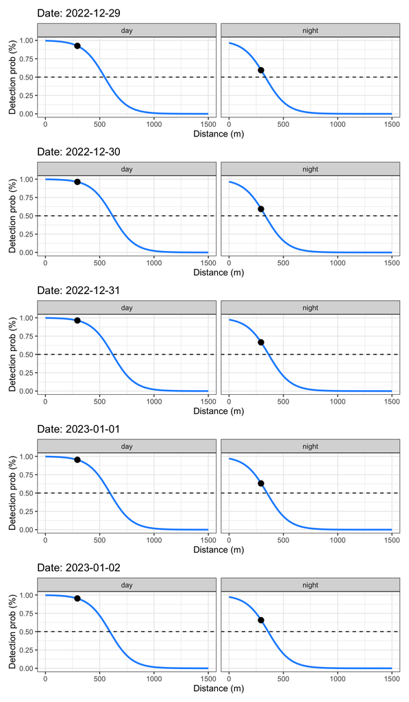

```r
for (i in 1:length(dates)) {
  aux_plot <- ggplot() + theme_bw() +
    geom_line(data = subset(daily_ranges$curves,
        station_name == "MIL 10" &
        date == dates[i]),
      aes(x = x, y = p),
      linewidth = 1,
      colour = "dodgerblue") +
    geom_point(data = subset(daily_ranges$ranges,
        station_name == "MIL 10" &
        date == dates[i]),
      aes(x = max_distance_detected, y = daily_efficiency),
      size = 3) +
    geom_hline(yintercept = 0.5, lty = "dashed") +
    labs(x = "Distance (m)", y = "Detection prob (%)",
      title = paste("Date:", dates[i])) +
    facet_wrap(~circadian)

  # Combine plots
  if (i == 1) {
    plot_curve <- aux_plot
  } else {
    plot_curve <- plot_curve / aux_plot
  }
}

plot_curve
```

gapFinder also has a **range diagnostics** function, that returns several summary statistics of range for each station (and circadian period).

```r
diag_ranges <- range_diag(input = daily_ranges,
  station_order = c("MIL 10"))

as.data.frame(diag_ranges)
```

```
##   station_name circadian days_range_prop min_transmitters
## 1       MIL 10       day               1                1
## 2       MIL 10     night               1                1
##   max_transmitters min_distance max_distance min_efficiency
## 1                1       294.17       294.17           0.78
## 2                1       294.17       294.17           0.59
##   mean_efficiency max_efficiency min_range mean_range max_range
## 1            0.95              1    418.99     596.71    897.65
## 2            0.81              1    333.69     477.41    897.65
##   min_cor_range mean_cor_range max_cor_range
## 1        444.14         614.65        915.45
## 2        353.99         498.47        915.45
```

We can use $ranges to plot the range timeseries (range = modelled range; cor_range = machine learning corrected ranges) for each station.

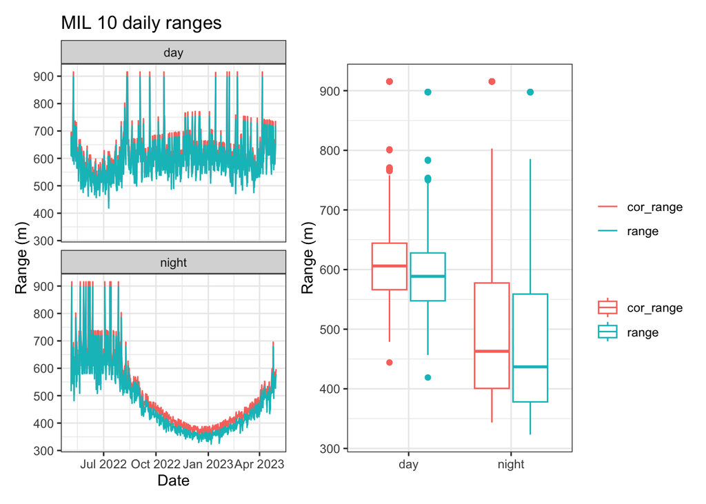

```r
ranges_long <- daily_ranges$ranges %>%
  pivot_longer(
    cols = c(cor_range, range),
    names_to = "range_type",
    values_to = "range_value"
  )

plot_ranges1 <- ggplot(ranges_long) +
  theme_bw() +
  geom_line(aes(x = date, y = range_value, colour = range_type)) +
  facet_wrap(~circadian, nrow = 2) +
  labs(x = "Date", y = "Range (m)", colour = "",
    title = "MIL 10 daily ranges")

plot_ranges2 <- ggplot(ranges_long) +
  theme_bw() +
  geom_boxplot(aes(x = circadian,
    y = range_value,
    group = interaction(circadian, range_type),
    colour = range_type)) +
  labs(x = "", y = "Range (m)", colour = "")

plot_ranges <- (plot_ranges1 | plot_ranges2) + plot_layout(guides = "collect")

plot_ranges
```

#### Environmental drivers of detection range

First we need to add circadian periods to the diagnostic data (OBS: to be added as a function in the package in the next update).

gapFinder defines day/night periods using **nautical dawn** and **nautical dusk** as the periods of reference.

First, lets use a single location reference point:

```r
lat <- dets_sort$diag$receiver_deployment_latitude[1]

lat
```

```
## [1] -42.66467
```

```r
lon <- dets_sort$diag$receiver_deployment_longitude[1]

lon
```

```
## [1] 148.2085
```

```r
# Parse timestamps in UTC, then derive the local time and local date
dets_sort$diag <- dets_sort$diag %>%
  mutate(
    local_time = with_tz(Time, "Australia/Hobart"),
    date = as.Date(local_time) # local calendar date, used for the join
  )

# Sunrise and sunset for each local date at receiver deployment
sun <- getSunlightTimes(
  date = unique(dets_sort$diag$date),
  lat = lat,
  lon = lon,
  keep = c("nauticalDawn", "nauticalDusk"),
  tz = "Australia/Hobart"
)

head(sun)
```

```
##         date       lat      lon        nauticalDawn
## 1 2022-05-04 -42.66467 148.2085 2022-05-04 05:57:42
## 2 2022-05-05 -42.66467 148.2085 2022-05-05 05:58:41
## 3 2022-05-06 -42.66467 148.2085 2022-05-06 05:59:40
## 4 2022-05-07 -42.66467 148.2085 2022-05-07 06:00:38
## 5 2022-05-08 -42.66467 148.2085 2022-05-08 06:01:35
## 6 2022-05-09 -42.66467 148.2085 2022-05-09 06:02:33
##          nauticalDusk
## 1 2022-05-04 18:12:46
## 2 2022-05-05 18:11:38
## 3 2022-05-06 18:10:31
## 4 2022-05-07 18:09:26
## 5 2022-05-08 18:08:22
## 6 2022-05-09 18:07:19
```

```r
# Assign day/night categories
dets_sort$diag <- dets_sort$diag %>%
  left_join(
    sun %>% dplyr::select(date, nauticalDawn, nauticalDusk),
    by = "date"
  ) %>%
  mutate(
    circadian = case_when(
      local_time >= nauticalDawn & local_time < nauticalDusk ~ "day",
      TRUE ~ "night"
    )
  )

# Sanity check
table(dets_sort$diag$circadian, useNA = "ifany")
```

```
##
##   day night
##  7088 10334
```

Plot diagnostic data and daily ranges:

```r
plot_eff <- ggplot() + theme_bw() +
  geom_line(data = daily_ranges$ranges,
    aes(x = date, y = daily_efficiency)) +
  labs(x = "Date", y = "Efficiency (%)") +
  facet_wrap(~circadian, nrow = 2)

plot_temp <- ggplot() + theme_bw() +
  geom_line(data = dets_sort$diag,
    aes(x = Time, y = as.numeric(`Ambient Temperature (deg C)`))) +
  labs(x = "Date", y = "Temperature (°C)") +
  facet_wrap(~circadian, nrow = 2)

plot_noise <- ggplot() + theme_bw() +
  geom_line(data = dets_sort$diag,
    aes(x = Time, y = as.numeric(`Noise Mean (mV)`))) +
  labs(x = "Date", y = "Noise (mV)") +
  facet_wrap(~circadian, nrow = 2)

plot_diag <- plot_eff | plot_temp | plot_noise
```

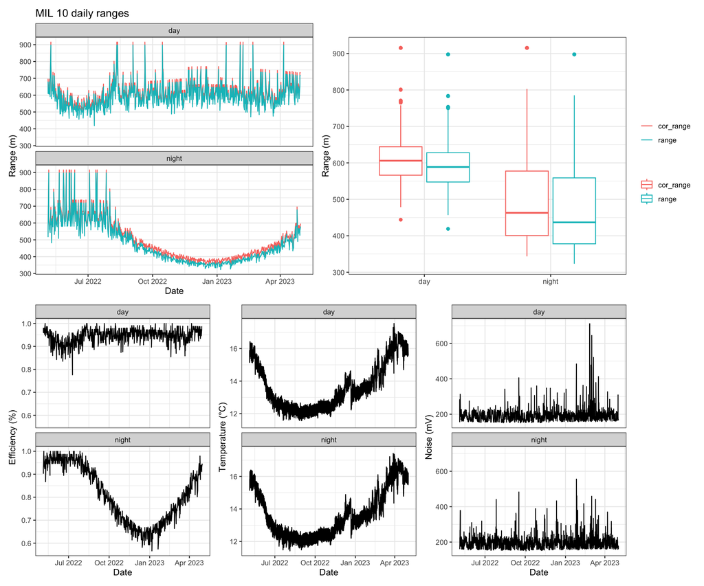

```r
plot_ranges / plot_diag
```

# Analysis Session 2

## 2.1. Quality control and visualising raw detection data

Live coding!

## 2.2. Home range analysis and habitat associations

Live coding!

# References